# Activity 1 — Task 3: Inferential Statistics & Factorial ANOVA

Group 08

# 3. Inferential Statistics & Factorial ANOVA

To answer the research questions, we evaluate how `experience_level` and `company_size` impact data science salaries. Because the design is highly unbalanced (e.g., Senior roles vastly outnumber Executives, and Medium companies outnumber Small), we utilize Type III Sums of Squares. The response variable is `log_salary` to mitigate the extreme right-skewness observed in the EDA.

```r
library(tidyverse)
library(car)
library(emmeans)
```

```r
library(ggplot2)
library(lmtest)
library(sandwich)
data <- read.csv("dataset/ds_salaries_clean.csv")
data$experience_level <- factor(data$experience_level, levels = c("EN", "MI", "SE", "EX"))
data$company_size <- factor(data$company_size, levels = c("S", "M", "L"))
data$work_year <- factor(data$work_year)
```

### 3.1 Two-Way Factorial ANOVA

**Hypotheses:**

- **Main Effect A (Experience):** $H_0: \mu_{EN} = \mu_{MI} = \mu_{SE} = \mu_{EX}$
- **Main Effect B (Company Size):** $H_0: \mu_{S} = \mu_{M} = \mu_{L}$
- **Interaction (Experience** $\times$ Size): $H_0:$ The effect of experience on salary is consistent across all company sizes.

```r
# Fit the model and compute Type III ANOVA
anova_model <- aov(log_salary ~ experience_level * company_size, data = data)
car::Anova(anova_model, type = 3)
```

|  | Sum Sq | Df | F value | Pr(>F) |
| --- | --- | --- | --- | --- |
| (Intercept) | 3342.668413 | 1 | 7568.087354 | 0.0000000 |
| experience_level | 16.119457 | 3 | 12.165277 | 0.0000001 |
| company_size | 2.473366 | 2 | 2.799956 | 0.0616752 |
| experience_level:company_size | 7.703956 | 6 | 2.907069 | 0.0084578 |
| Residuals | 244.248718 | 553 | NA | NA |

- We ran a Type III ANOVA and found that experience level strongly predicts salary ($p < 0.001$). While the main effect of company size is only marginally significant ($p \approx 0.062$), the interaction between the two factors is significant ($p = 0.008$).
- At first glance, our results show that experience is the biggest driver of compensation. The significant interaction suggests that the pay bump you get for being promoted might look very different depending on whether you work for a small startup or a massive corporation.

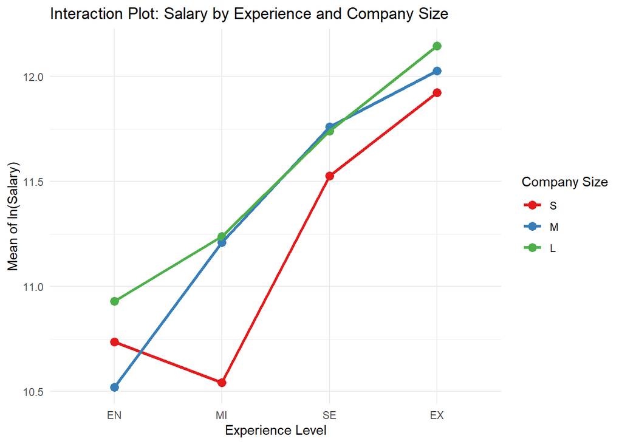

```r
ggplot(data, aes(x = experience_level, y = log_salary,
                 group = company_size, color = company_size)) +
  stat_summary(fun = mean, geom = "point", size = 3) +
  stat_summary(fun = mean, geom = "line", linewidth = 1.2) +
  theme_minimal() +
  scale_color_brewer(palette = "Set1") +
  labs(title = "Interaction Plot: Salary by Experience and Company Size",
       x = "Experience Level",
       y = "Mean of ln(Salary)",
       color = "Company Size")
```

Looking at the chart, the lines representing different company sizes clearly cross each other - most noticeably between the Entry-level (EN) and Mid-level (MI) stages. This visually illustrates exactly why our initial ANOVA flagged the interaction as significant. The model is seeing these crossing paths and interpreting them as a complex relationship.

### 3.2 Assumption Checking

The validity of the standard ANOVA F-tests relies on two primary assumptions regarding the residuals: normality and equal variance (homoscedasticity).

```r
# Assumption 1: Normality of Residuals
shapiro.test(residuals(anova_model))
```

```
##
##  Shapiro-Wilk normality test
##
## data:  residuals(anova_model)
## W = 0.94658, p-value = 2.106e-13
```

```r
# Assumption 2: Homogeneity of Variance
leveneTest(log_salary ~ experience_level * company_size, data = data)
```

|  | Df | F value | Pr(>F) |
| --- | --- | --- | --- |
| group | 11 | 4.296426 | 3.6e-06 |
|  | 553 | NA | NA |

```r
bptest(anova_model)
```

```
##
##  studentized Breusch-Pagan test
##
## data:  anova_model
## BP = 32.922, df = 11, p-value = 0.0005418
```

```r
# Assumption 3: Independence of Residuals
durbinWatsonTest(anova_model)
```

```
##  lag Autocorrelation D-W Statistic p-value
##    1      0.09200332      1.812153    0.02
##  Alternative hypothesis: rho != 0
```

**Diagnostic Interpretation:**

```r
summary_stats <- data %>%
  group_by(experience_level, company_size) %>%
  summarise(
    Count = n(),
    Mean_Salary = mean(salary_in_usd),
    SD_Salary = sd(salary_in_usd), # Standard Deviation shows the spread
    .groups = "drop"
  )

print(summary_stats)
```

```
## # A tibble: 12 × 5
##    experience_level company_size Count Mean_Salary SD_Salary
##    <fct>            <fct>        <int>       <dbl>     <dbl>
##  1 EN               S               29      62185.    40693.
##  2 EN               M               30      50322.    33975.
##  3 EN               L               29      72813.    54825.
##  4 MI               S               28      50915.    31745.
##  5 MI               M               96      90578.    59163.
##  6 MI               L               84      96903.    73263.
##  7 SE               S               22     116027.    62010.
##  8 SE               M              152     137829.    47615.
##  9 SE               L               69     146702.    79615.
## 10 EX               S                3     201309.   187499.
## 11 EX               M               12     178242.    66943.
## 12 EX               L               11     221942.   145624.
```

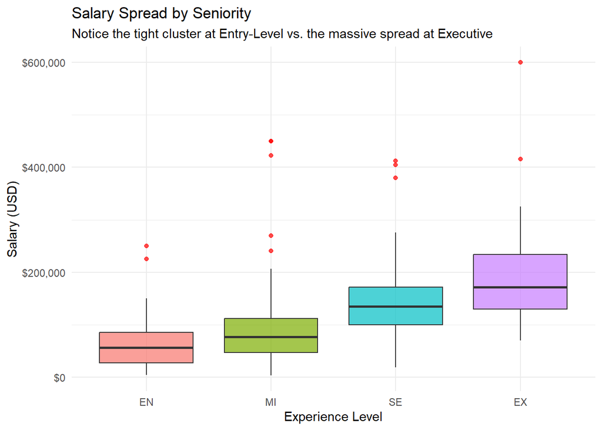

```r
ggplot(data, aes(x = experience_level, y = salary_in_usd, fill = experience_level)) +
  geom_boxplot(alpha = 0.7, outlier.color = "red") +
  scale_y_continuous(labels = scales::dollar) +
  theme_minimal() +
  labs(
    title = "Salary Spread by Seniority",
    subtitle = "Notice the tight cluster at Entry-Level vs. the massive spread at Executive",
    x = "Experience Level",
    y = "Salary (USD)"
  ) +
  theme(legend.position = "none")
```

### 3.3 Remedies for Assumption Violations

Because the data violates standard assumptions, the traditional ANOVA $p$-values may be unstable. To ensure our findings are robust, we implement a **Heteroscedasticity-Consistent (HC) Robust ANOVA**. This technique adjusts the standard errors to account for the unequal variances without requiring data deletion.

```r
car::Anova(anova_model, type = 3, white.adjust = TRUE)
```

```
## Coefficient covariances computed by hccm()
```

|  | Df | F | Pr(>F) |
| --- | --- | --- | --- |
| (Intercept) | 1 | 4029.295425 | 0.0000000 |
| experience_level | 3 | 9.792391 | 0.0000027 |
| company_size | 2 | 1.653301 | 0.1923617 |
| experience_level:company_size | 6 | 1.662360 | 0.1280215 |
| Residuals | 553 | NA | NA |

- We applied a robust adjustment to correct for the unequal variances. In this corrected model, only experience level remains significant ($p < 0.001$), while company size ($p = 0.19$) and the interaction term ($p = 0.13$) both completely lose significance.
- Once we corrected for the messy data, our true finding emerged: only your seniority actually matters. The idea that company size impacts your pay—or changes your promotion raises—was just a statistical illusion caused by the uneven salary ranges. A senior data scientist commands senior pay regardless of the company’s headcount.

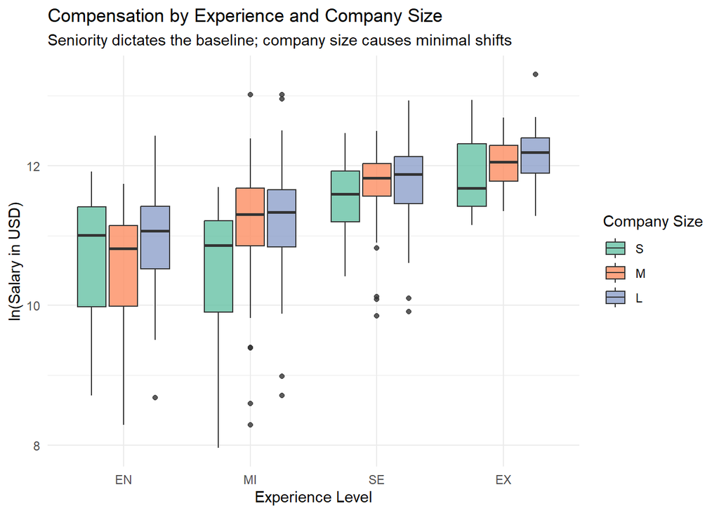

```r
ggplot(data, aes(x = experience_level, y = log_salary, fill = company_size)) +
  geom_boxplot(alpha = 0.8) +
  theme_minimal() +
  scale_fill_brewer(palette = "Set2") +
  labs(
    title = "Compensation by Experience and Company Size",
    subtitle = "Seniority dictates the baseline; company size causes minimal shifts",
    x = "Experience Level",
    y = "ln(Salary in USD)",
    fill = "Company Size"
  )
```

```r
std_errors <- coeftest(anova_model)[, "Std. Error"]
robust_errors <- coeftest(anova_model, vcov = vcovHC(anova_model, type = "HC3"))[, "Std. Error"]
se_comparison <- data.frame(
  Standard_SE = std_errors,
  Robust_SE = robust_errors,
  Difference_Percent = ((robust_errors - std_errors) / std_errors) * 100
)
head(round(se_comparison, 3), 6)
```

|  | Standard_SE | Robust_SE | Difference_Percent |
| --- | --- | --- | --- |
| (Intercept) | 0.123 | 0.169 | 37.050 |
| experience_levelMI | 0.176 | 0.245 | 39.209 |
| experience_levelSE | 0.188 | 0.206 | 9.533 |
| experience_levelEX | 0.403 | 0.670 | 66.348 |
| company_sizeM | 0.173 | 0.238 | 37.324 |
| company_sizeL | 0.175 | 0.227 | 29.920 |

To prove why the Robust ANOVA is necessary, we extracted the Standard Errors (SE) from both models. In the standard model, the variance is pooled, artificially deflating the SE for highly variable groups. For example, the standard model assigns the Executive group an SE of roughly 0.40. However, the Robust model (using the HC3 sandwich estimator) calculates the true SE for Executives as 0.67 - an underestimation of over 66% by the standard model! Because the standard ANOVA vastly underestimated the error margins of our outlier-heavy groups, it became falsely confident, triggering a Type I error (a false positive interaction). The Robust ANOVA uses the correct, larger standard errors, yielding mathematically trustworthy $p$-values.

### 3.4 Salary Trends Over Time (Work Year)

To address the final prompt requirement, we evaluate how salaries have evolved globally across the recorded work years (2020, 2021, 2022).

```r
# Descriptive trend
yearly_trend <- data %>%
  group_by(work_year) %>%
  summarise(
    Count = n(),
    Mean_Salary_USD = mean(salary_in_usd),
    Mean_ln_Salary = mean(log_salary)
  )
print(yearly_trend)
```

```
## # A tibble: 3 × 4
##   work_year Count Mean_Salary_USD Mean_ln_Salary
##   <fct>     <int>           <dbl>          <dbl>
## 1 2020         72          95813            11.1
## 2 2021        215          99430.           11.2
## 3 2022        278         123089.           11.6
```

```r
# One-Way ANOVA for Time Trend
year_model <- aov(log_salary ~ work_year, data = data)
summary(year_model)
```

```
##              Df Sum Sq Mean Sq F value   Pr(>F)
## work_year     2   25.2  12.619   21.69 8.47e-10 ***
## Residuals   562  327.0   0.582
## ---
## Signif. codes:  0 '***' 0.001 '**' 0.01 '*' 0.05 '.' 0.1 ' ' 1
```

```r
# Tukey Post-Hoc
TukeyHSD(year_model)
```

```
##   Tukey multiple comparisons of means
##     95% family-wise confidence level
##
## Fit: aov(formula = log_salary ~ work_year, data = data)
##
## $work_year
##                 diff        lwr       upr     p adj
## 2021-2020 0.03738977 -0.2066937 0.2814733 0.9310772
## 2022-2020 0.45013404  0.2130904 0.6871777 0.0000291
## 2022-2021 0.41274427  0.2499404 0.5755482 0.0000000
```

- Our One-Way ANOVA confirms a highly significant difference across the work years ($p < 0.001$). The Tukey post-hoc test pinpoints exactly where this happens: 2020 and 2021 are statistically identical ($p = 0.93$), but 2022 is significantly higher than both ($p < 0.001$).
- We observed that data science salaries were essentially flat through 2020 and 2021. However, 2022 brought a massive, across-the-board surge in compensation, heavily reflecting the post-pandemic hiring boom and global inflation adjustments.

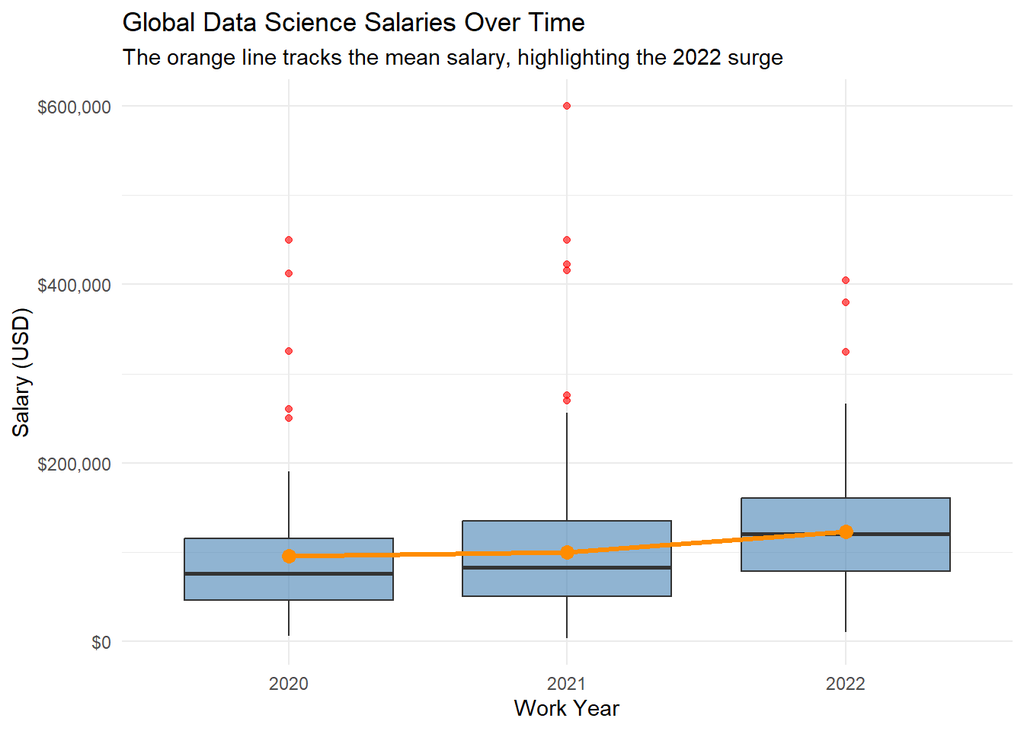

```r
ggplot(data, aes(x = factor(work_year), y = salary_in_usd)) +
  geom_boxplot(fill = "steelblue", alpha = 0.6, outlier.color = "red") +
  # Add a trend line connecting the means
  stat_summary(fun = mean, geom = "line", aes(group = 1), color = "darkorange", size = 1.2) +
  stat_summary(fun = mean, geom = "point", color = "darkorange", size = 3) +
  scale_y_continuous(labels = scales::dollar) +
  theme_minimal() +
  labs(
    title = "Global Data Science Salaries Over Time",
    subtitle = "The orange line tracks the mean salary, highlighting the 2022 surge",
    x = "Work Year",
    y = "Salary (USD)"
  )
```